# Practical Machine Learning - Coursera Final Project

*Igor Dutra Cavalcante, 22 de agosto de 2020*

### Overview

This is the final project of the Practical Machine Learning course. The goal is to predict the manner in which they did the exercise, through the other variables.

### Dados iniciais (Initial data)

The training data for this project are available here: https://d396qusza40orc.cloudfront.net/predmachlearn/pml-training.csv

The test data are available here: https://d396qusza40orc.cloudfront.net/predmachlearn/pml-testing.csv

The data for this project come from this source: http://groupware.les.inf.puc-rio.br/har. If you use the document you create for this class for any purpose please cite them as they have been very generous in allowing their data to be used for this kind of assignment.

### Bibliotecas (Libraries)

```r
library(caret)
library(dplyr)
library(corrplot)
library(RColorBrewer)
```

First, we must download and clean the data.

### Leitura dos dados (Reading data)

```r
treino <- read.csv("https://d396qusza40orc.cloudfront.net/predmachlearn/pml-training.csv", header = T, stringsAsFactors = F)
teste  <- read.csv("https://d396qusza40orc.cloudfront.net/predmachlearn/pml-testing.csv", header = T, stringsAsFactors = F)
dim(treino)
# [1] 19622   160
dim(teste)
# [1]  20 160
head(treino)
str(treino)
```

To optimize, variables deemed to have a low potential for predictive value were removed.

### Limpeza dos dados (Cleaning data)

```r
treino <- treino[, -nearZeroVar(treino)]
teste  <- teste[, -nearZeroVar(teste)]
treino <- treino[, (colSums(is.na(treino)) == 0)]
teste  <- teste[, (colSums(is.na(teste)) == 0)]
treino <- select(treino, -c(X, user_name, raw_timestamp_part_1, raw_timestamp_part_2, cvtd_timestamp, num_window))
teste  <- select(teste, -c(X, user_name, raw_timestamp_part_1, raw_timestamp_part_2, cvtd_timestamp, num_window))
treino$classe <- as.factor(treino$classe)
```

Once the data is clean and the features with no predictive value are discarded, we will check the correlation strength between the remaining features.

### Correlação (Correlation)

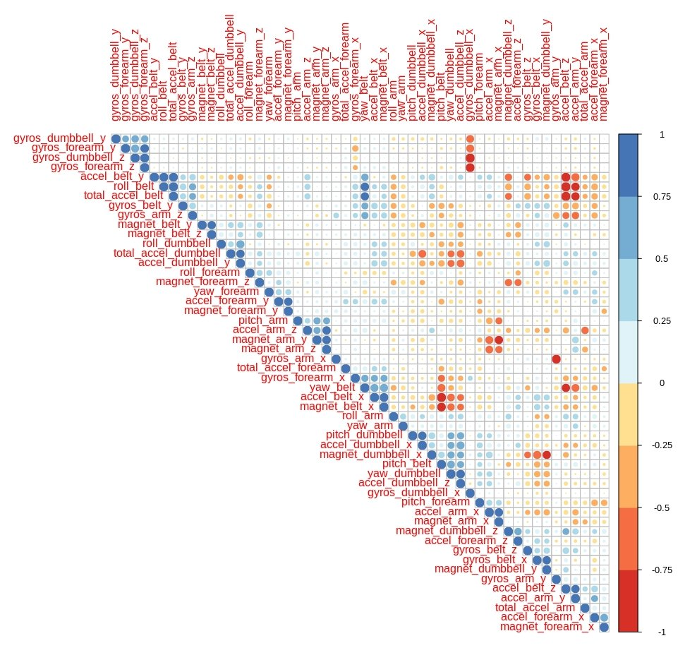

```r
cor(treino[,-ncol(treino)]) %>%
  corrplot(type="upper", order="hclust", col=brewer.pal(n=8, name="RdYlBu"))
```

The cross-validation method was then used. This method separates the training data (70%) and validation (30%), allowing for better model validation.

### Divisão (Partioning)

```r
set.seed(1111)
emTreino   <- createDataPartition(treino$classe, p = 0.70, list = FALSE)
validacao  <- treino[-emTreino, ]
treino     <- treino[emTreino, ]
```

The model was then trained using the Generalized Boosted Model method.

### Predição com método GBM (Prediction with GBM method)

```r
mod_gbm  <- train(classe ~., data = treino, method = "gbm")
pred_gbm <- predict(mod_gbm, validacao)
confMatrix <- confusionMatrix(validacao$classe, pred_gbm)
```

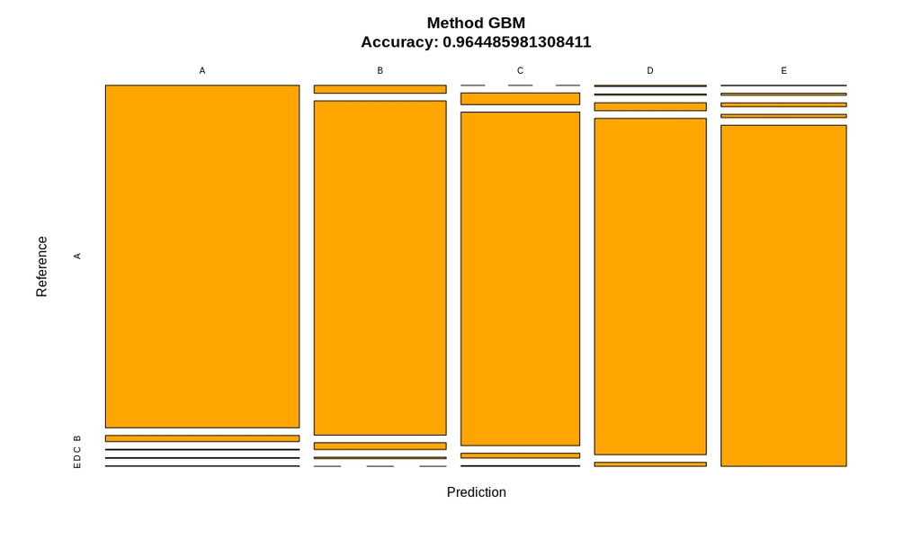

```r
confMatrix$table %>%
  plot(main = paste("Method GBM\nAccuracy:", confMatrix$overall['Accuracy']), col="orange")
```

Finally, let's test the model in the test cases:

```r
predict(mod_gbm, teste)
# [1] B A B A A E D B A A B C B A E E A B B B
```